# SAR flood detectability — Mumbai 2024

When no Sentinel-1 pass falls near the flood peak: is the event date separable from the rest of the season?

Author

Manish Bilore

Published

September 24, 2026

**mumbai 2024 — no acquisition near the flood peak.** Relative orbit 34 is the only track over this area, at a 12-day repeat: 9 passes in the season. The pass under test is **2024-07-11**. Verdict: the event date is **NOT SEPARABLE** from the rest of the season.

# 1 Why this event gets a different report

Every other event in this project had a Sentinel-1 acquisition inside the flood peak, so a map of that scene *is* a flood map. Here it does not. Urban pluvial flooding in Mumbai drains within hours of the rain stopping, while the satellite returns every 12 days on a single track — so the question is not “how much flooding does the map show” but **“could this system have seen the flood at all?”**

The test: apply the identical classical rule to **every** pass of the monsoon, and compare the event date against the others. If the flood left a detectable signature, the event date should stand out from the seasonal and tidal spread. If it does not, the extent measured on that date is indistinguishable from an ordinary wet-season scene — which is the answer, and a limit of the observing system rather than of the method.

# 2 Acquisitions

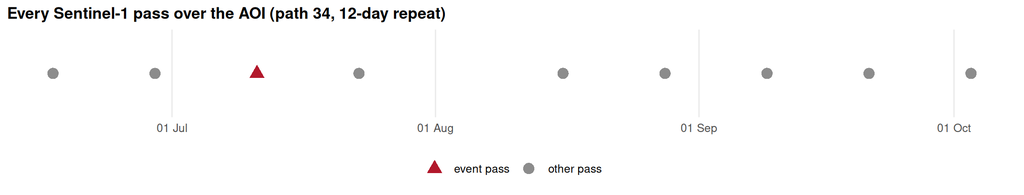

# 3 Water extent across the season

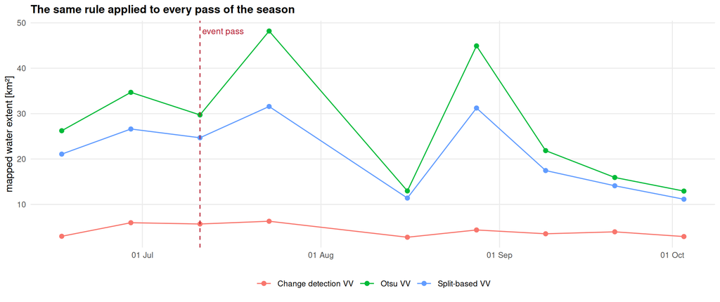

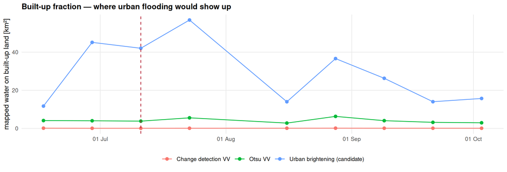

# 4 Is the event date separable?

| method | event km² | season mean km² | season sd | season max km² | z-score | rank in season | min detectable km² | separable |
| --- | --- | --- | --- | --- | --- | --- | --- | --- |
| Change detection VV | 5.69 | 4.10 | 1.37 | 6.29 | 1.16 | 3 | 2.74 | FALSE |
| Otsu VV | 29.71 | 27.22 | 14.01 | 48.19 | 0.18 | 4 | 28.01 | FALSE |
| Split-based VV | 24.68 | 20.58 | 8.42 | 31.58 | 0.49 | 4 | 16.84 | FALSE |
| Urban brightening (candidate) | 42.04 | 27.54 | 16.95 | 56.87 | 0.86 | 3 | 33.91 | FALSE |

**z-score** is how many seasonal standard deviations the event pass sits above the mean of the other passes; **rank** is its position among all 9 passes (1 = largest extent of the season). A flood that the sensor caught should score z ≥ 2 and rank 1 on every sound method.

Here it does neither: the classical methods put the event pass at z = 1.16 / 0.18 / 0.49 and rank 3 / 4 / 4 of 9. The extent mapped on 2024-07-11 is **inside the ordinary spread of the season** — what any single scene shows in this AOI is dominated by permanently wet ground, creeks and antecedent rainfall rather than by the flood. Whatever water the event left on the surface was either gone by the overpass or too small and too mixed with buildings to register at 10 m.

The same table sets a **detection floor** for this AOI and sampling. Season-to-season scatter is 1.4–14.0 km² (1 sd), so a flood has to add **3–28 km² of newly mapped water** before it clears z = 2 — against a seasonal mean of 4–27 km². The 11 July pass added +1.6–+4.1 km². That floor, not the choice of threshold or model, is what decides whether an event of this kind is observable at all.

# 5 Event pass against its closest rival

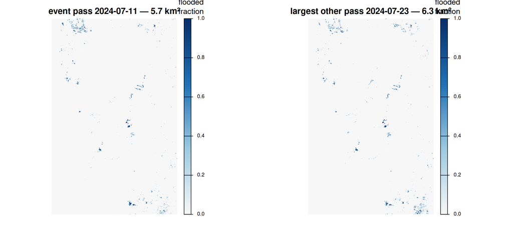

If the two panels look alike, that is the finding: the event pass is another wet-season scene.

# 6 What this means for monitoring

- **Revisit, not method, is the binding constraint for urban pluvial floods.** A 12-day repeat on one track cannot be expected to catch water that drains in hours. No amount of threshold tuning or deep learning changes that.
- **Geometry matters as much as timing.** Only one relative orbit covers this AOI, so there is no second chance from an ascending pass a few hours later on the same day.
- **What would work**: a constellation with sub-daily revisit (Sentinel-1 C + D from 2026, or commercial X-band tasking), or a different observable — rain-gauge and drainage-network data for the event itself, with SAR reserved for the slower riverine and coastal flooding it does see well.
- The rest of this project shows the method working where an acquisition exists (Kerala, Assam). This page is the honest boundary of that claim.

**Caveats.** The comparison uses one relative orbit (34) and identical processing on every date, so the passes are directly comparable; the thresholds are re-estimated per scene, as they would be operationally. Tidal stage is not controlled — the intertidal band is masked, but creeks and mudflats still move between passes, which is part of the seasonal spread being measured. A flood too small or too brief to register at 10 m would also produce this result; separability is evidence about the observing system, not proof that no water was present.